# Tarea 1.3 Bioinformatica Reproducible para Analisis Genomicos

Pablo Valenzuela-Carvajal, pablo.valenzuela.c@ug.uchile.cl Profesor: Dr. Ricardo Verdugo

22 de septiembre, 2026

## Ejercicio 1

Crea una variable con el logaritmo base 10 de 50 y súmalo a otra variable cuyo valor sea igual a 5.

```r
log50<-log(x=50,
           base=10)

cinco<-5

log50+cinco
```

```
[1] 6.69897
```

## Ejercicio 2

Suma el número 2 a todos los números entre 1 y 150.

```r
1:150+2
```

```
  [1]   3   4   5   6   7   8   9  10  11  12  13  14  15  16  17  18  19  20
 [19]  21  22  23  24  25  26  27  28  29  30  31  32  33  34  35  36  37  38
 [37]  39  40  41  42  43  44  45  46  47  48  49  50  51  52  53  54  55  56
 [55]  57  58  59  60  61  62  63  64  65  66  67  68  69  70  71  72  73  74
 [73]  75  76  77  78  79  80  81  82  83  84  85  86  87  88  89  90  91  92
 [91]  93  94  95  96  97  98  99 100 101 102 103 104 105 106 107 108 109 110
[109] 111 112 113 114 115 116 117 118 119 120 121 122 123 124 125 126 127 128
[127] 129 130 131 132 133 134 135 136 137 138 139 140 141 142 143 144 145 146
[145] 147 148 149 150 151 152
```

## Ejercicio 3

¿Cuántos números son mayores a 20 en el vector -13432:234?

```r
sum(-13432:234>20)
```

```
[1] 214
```

## Ejercicio 4

Carga en R el archivo `PracUni1Ses3/maices/meta/maizteocintle_SNP50k_meta_extended.txt` y ponlo en un objeto de R llamado meta_maiz.

```r
meta_maiz<-read.delim(file="./PracUni1Ses3/maices/meta/maizteocintle_SNP50k_meta_extended.txt",
           header=TRUE,
           sep="\t",
           fileEncoding="latin1")
```

## Ejercicio 5

Escribe un for loop para que divida 35 entre 1:10 e imprima el resultado en la consola.

```r
for (i in 1:10) {
  div <- 35/i
  print(div)
}
```

```
[1] 35
[1] 17.5
[1] 11.66667
[1] 8.75
[1] 7
[1] 5.833333
[1] 5
[1] 4.375
[1] 3.888889
[1] 3.5
```

Modifica el loop anterior para que haga las divisiones solo para los números nones (con un comando, NO con c(1,3,…)). Pista: next.

```r
for (i in 1:10) {
  if (i%%2) {
    div <- 35/i
    cat("la división de 35 por",i,"es:",div,"\n")
  } else {
  cat("El numero es par(",i, "), por lo que no se realizará la división \n")
} }
```

```
la división de 35 por 1 es: 35
El numero es par( 2 ), por lo que no se realizará la división
la división de 35 por 3 es: 11.66667
El numero es par( 4 ), por lo que no se realizará la división
la división de 35 por 5 es: 7
El numero es par( 6 ), por lo que no se realizará la división
la división de 35 por 7 es: 5
El numero es par( 8 ), por lo que no se realizará la división
la división de 35 por 9 es: 3.888889
El numero es par( 10 ), por lo que no se realizará la división
```

Modifica el loop anterior para que los resultados de correr todo el loop se guarden en una df de dos columnas, la primera debe tener el texto “resultado para x” (donde x es cada uno de los elementos del loop) y la segunda el resultado correspondiente a cada elemento del loop.

```r
resultado <- data.frame(
  texto = character(),
  resultado = numeric()
)

for (i in 1:10) {

    div <- 35/i
    resultado <- rbind(resultado, data.frame(texto = paste("resultado para", i),
                                             resultado = div))
  }


resultado
```

```
               texto resultado
1   resultado para 1 35.000000
2   resultado para 2 17.500000
3   resultado para 3 11.666667
4   resultado para 4  8.750000
5   resultado para 5  7.000000
6   resultado para 6  5.833333
7   resultado para 7  5.000000
8   resultado para 8  4.375000
9   resultado para 9  3.888889
10 resultado para 10  3.500000
```

## Ejercicio 6

Abre en RStudio el script `PracUni1Ses3/mantel/bin/1.IBR_testing.r`. Este script realiza un análisis de [aislamiento por resistencia](http://www.bioone.org/doi/abs/10.1554/05-321.1) con Fst calculadas con ddRAD en *Berberis alpina*.

Lee el código del script y determina:

**¿Qué hacen los dos for loops del script?**

El primer bucle `for` hace lo siguiente:

1. Construye la ruta al archivo de salida de Circuitscape (Balpina__resistances.out), que contiene las distancias efectivas (effective distances) entre puntos bajo ese modelo de resistencia.
2. Lee la matriz de distancias efectivas con la función personal `read.effdist()`, reordenando las poblaciones según el orden de popNames.
3. Calcula la media de distancia efectiva por población `(apply(..., 2, mean))`.
4. Guarda en el entorno global dos objetos por cada escenario: B. (matriz de distancias efectivas) y B.mean. (vector de medias).

y el siguiente bucle `for`

1. Ejecuta un test de Mantel (`mantel.rtest` del paquete `ade4`, con 10000 permutaciones) entre la matriz de distancias efectivas B. y la matriz de Fst (B.FstLin = Fst/(1-Fst)).
2. Imprime los resultados.
3. Genera un gráfico de dispersión con la función personal `DistPlot()`.
4. Extrae el p-valor y la r de Mantel observada, redondeados.
5. Acumula los resultados en la matriz `IBRresults` (una fila por escenario: nombre, p-valor, r).

**¿Qué paquetes necesitas para correr el script?**

Los paquetes necesarios para correr el script son `ade4`, `ggplot2` y `sp`

**¿Qué archivos necesitas para correr el script?**

Se necesitan los archivos:

- `surveyed_mountains.tsv`
- `BerSS.sumstats.tsv`
- `BerSS.fst_summary.tsv`
- `Balpina_focalpoints.txt`
- Los .out generados en `/redist`

## Ejercicio 7

Escribe una función llamada calc.tetha que te permita calcular tetha dados Ne y u como argumentos. Recuerda que tetha=4Neu.

```r
calc.tetha<-function(Ne, u){

  # Red banannas

  tetha<-4*Ne*u

  return(tetha)
}

calc.tetha(Ne=10000,u=1*10^-8)
```

```
[1] 4e-04
```

## Ejercicio 8

Al script del ejercicio de las pruebas de Mantel, agrega el código necesario para realizar un Partial Mantel test entre la matriz Fst, y las matrices del presente y el LGM, parcializando la matriz flat. Necesitarás el paquete vegan.

```
[1] "Partial Mantel results for present"
```

```
'nperm' >= set of all permutations: complete enumeration.
```

```
Set of permutations < 'minperm'. Generating entire set.
```

```
Partial Mantel statistic based on Pearson's product-moment correlation

Call:
mantel.partial(xdis = B.scen.dist, ydis = B.FstLin.dist, zdis = B.flat.dist,      method = "pearson", permutations = 10000)

Mantel statistic r: 0.05878
      Significance: 0.44722

Upper quantiles of permutations (null model):
  90%   95% 97.5%   99%
0.377 0.468 0.550 0.672
Permutation: free
Number of permutations: 719
```

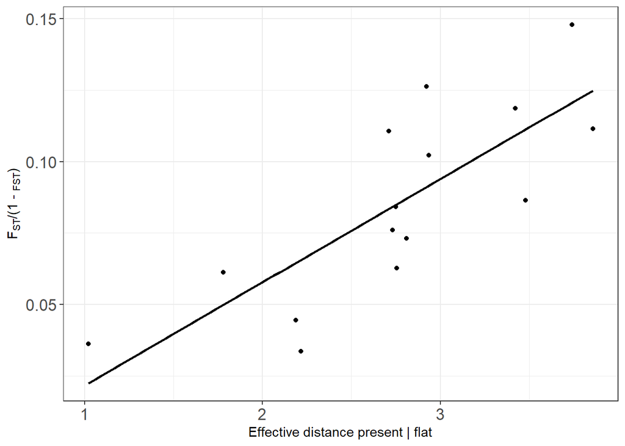

```
Analysis of Variance Table

Response: GenDist
          Df    Sum Sq   Mean Sq F value    Pr(>F)
Dist       1 0.0101674 0.0101674   21.19 0.0004948 ***
Residuals 13 0.0062377 0.0004798
---
Signif. codes:  0 '***' 0.001 '**' 0.01 '*' 0.05 '.' 0.1 ' ' 1

Call:
lm(formula = GenDist ~ Dist, data = df)

Residuals:
      Min        1Q    Median        3Q       Max
-0.032042 -0.016958 -0.000703  0.012643  0.035229

Coefficients:
             Estimate Std. Error t value Pr(>|t|)
(Intercept) -0.014513   0.022353  -0.649 0.527476
Dist         0.036141   0.007851   4.603 0.000495 ***
---
Signif. codes:  0 '***' 0.001 '**' 0.01 '*' 0.05 '.' 0.1 ' ' 1

Residual standard error: 0.0219 on 13 degrees of freedom
Multiple R-squared:  0.6198,    Adjusted R-squared:  0.5905
F-statistic: 21.19 on 1 and 13 DF,  p-value: 0.0004948

[1] "Partial Mantel results for ccsm"
```

```
'nperm' >= set of all permutations: complete enumeration.
Set of permutations < 'minperm'. Generating entire set.
```

```
Partial Mantel statistic based on Pearson's product-moment correlation

Call:
mantel.partial(xdis = B.scen.dist, ydis = B.FstLin.dist, zdis = B.flat.dist,      method = "pearson", permutations = 10000)

Mantel statistic r: -0.06078
      Significance: 0.59583

Upper quantiles of permutations (null model):
  90%   95% 97.5%   99%
0.353 0.447 0.507 0.639
Permutation: free
Number of permutations: 719
```

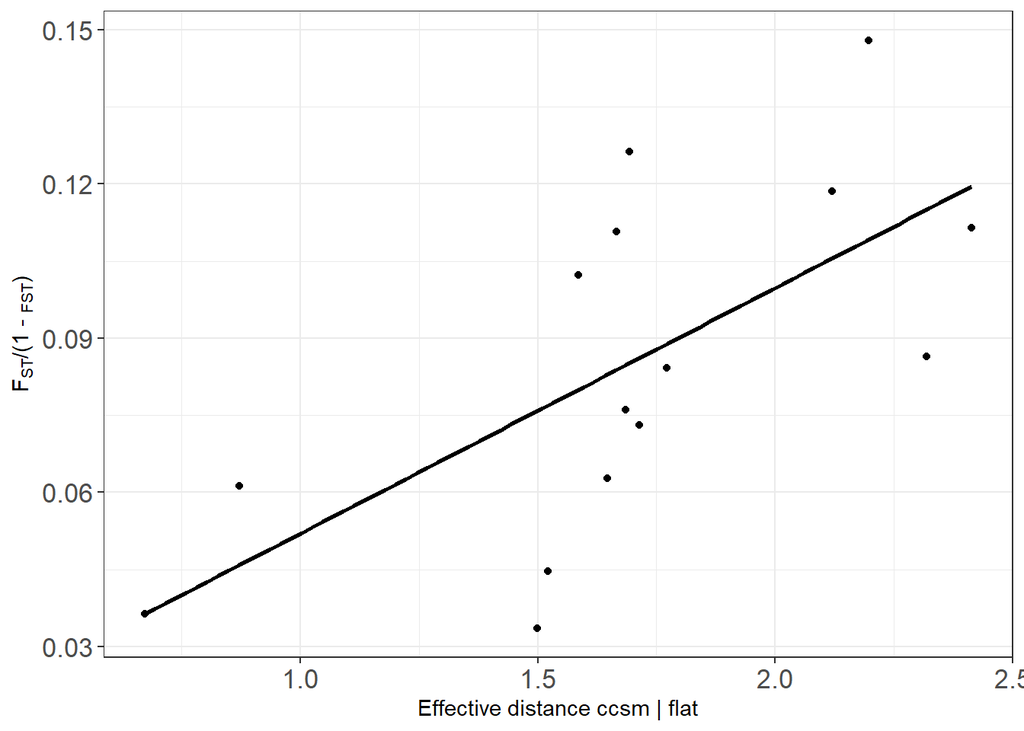

```
Analysis of Variance Table

Response: GenDist
          Df    Sum Sq   Mean Sq F value   Pr(>F)
Dist       1 0.0071985 0.0071985  10.164 0.007128 **
Residuals 13 0.0092067 0.0007082
---
Signif. codes:  0 '***' 0.001 '**' 0.01 '*' 0.05 '.' 0.1 ' ' 1

Call:
lm(formula = GenDist ~ Dist, data = df)

Residuals:
      Min        1Q    Median        3Q       Max
-0.042246 -0.016591 -0.004692  0.018877  0.041177

Coefficients:
            Estimate Std. Error t value Pr(>|t|)
(Intercept) 0.004198   0.026270   0.160  0.87550
Dist        0.047781   0.014987   3.188  0.00713 **
---
Signif. codes:  0 '***' 0.001 '**' 0.01 '*' 0.05 '.' 0.1 ' ' 1

Residual standard error: 0.02661 on 13 degrees of freedom
Multiple R-squared:  0.4388,    Adjusted R-squared:  0.3956
F-statistic: 10.16 on 1 and 13 DF,  p-value: 0.007128

[1] "Partial Mantel results for miroc"
```

```
'nperm' >= set of all permutations: complete enumeration.
Set of permutations < 'minperm'. Generating entire set.
```

```
Partial Mantel statistic based on Pearson's product-moment correlation

Call:
mantel.partial(xdis = B.scen.dist, ydis = B.FstLin.dist, zdis = B.flat.dist,      method = "pearson", permutations = 10000)

Mantel statistic r: 0.2183
      Significance: 0.24722

Upper quantiles of permutations (null model):
  90%   95% 97.5%   99%
0.385 0.492 0.597 0.722
Permutation: free
Number of permutations: 719
```

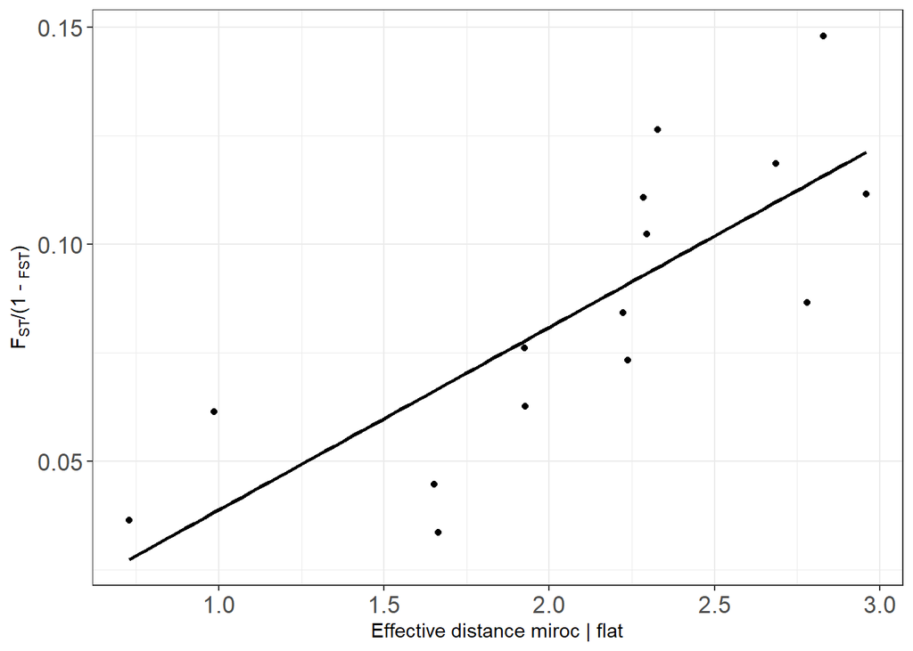

```
Analysis of Variance Table

Response: GenDist
          Df    Sum Sq   Mean Sq F value    Pr(>F)
Dist       1 0.0102884 0.0102884  21.866 0.0004335 ***
Residuals 13 0.0061168 0.0004705
---
Signif. codes:  0 '***' 0.001 '**' 0.01 '*' 0.05 '.' 0.1 ' ' 1

Call:
lm(formula = GenDist ~ Dist, data = df)

Residuals:
     Min       1Q   Median       3Q      Max
-0.03313 -0.01639 -0.00158  0.01349  0.03221

Coefficients:
             Estimate Std. Error t value Pr(>|t|)
(Intercept) -0.003356   0.019715  -0.170 0.867445
Dist         0.042086   0.009000   4.676 0.000434 ***
---
Signif. codes:  0 '***' 0.001 '**' 0.01 '*' 0.05 '.' 0.1 ' ' 1

Residual standard error: 0.02169 on 13 degrees of freedom
Multiple R-squared:  0.6271,    Adjusted R-squared:  0.5985
F-statistic: 21.87 on 1 and 13 DF,  p-value: 0.0004335
```

```r
setwd("./PracUni1Ses3/mantel/bin")
source("1.1 IBR Partial.r")
```

## Ejercicio 9

Escribe un script que debe estar guardado en `PracUni1Ses3/maices/bin` y llamarse `ExplorandoMaiz.R`, que 1) cargue en R el archivo `PPracUni1Ses3maices/meta/maizteocintle_SNP50k_meta_extended.txt` y 2) responda lo siguiente.

**¿Qué tipo de objeto creamos al cargar la base?** Se crea un objeto de clase `data.frame`

**¿Cómo se ven las primeras 6 líneas del archivo?** Se incluye en la salida del script, es una base de datos con 22 variables

**¿Cuántas muestras hay?** Hay un total de 165 muestras

**¿De cuántos estados se tienen muestras?** De un total de 16 estados

**¿Cuántas muestras fueron colectadas antes de 1980?** 8 muestras fueron colectadas antes de 1980, luego de remover los NA

**¿Cuántas muestras hay de cada raza?** Se puede observar en el codigo, la tabla corresponde a la linea `>table(tabla_maices$Raza)`

**En promedio ¿a qué altitud fueron colectadas las muestras?** El promedio de altura fue de 1519.242 msnm.

**¿Y a qué altitud máxima y mínima fueron colectadas?** La altura minima fue de 5 msnm y la altura maxima fue de 2769 msnm.

**Crea una nueva df de datos sólo con las muestras de la raza Olotillo**

**Crea una nueva df de datos sólo con las muestras de la raza Reventador, Jala y Ancho**

**Escribe la matriz anterior a un archivo llamado “submat.cvs” en /meta.**

Los ultimos tres ejercicios se pueden observar en el codigo a continuación

```r
setwd("./PracUni1Ses3/maices/bin")

source("ExplorandoMaiz.R", echo = TRUE, print.eval = TRUE)
```

```
> tabla_maices <- read.delim(file = "../meta/maizteocintle_SNP50k_meta_extended.txt",
+     header = TRUE, sep = "\t", fileEncoding = "latin1")

> class(tabla_maices)
[1] "data.frame"

> head(tabla_maices)
  OrderColecta NSiembra          Origen                  Raza     Estado
1            2        3  INIFAP-2009-16              Apachito  Chihuahua
2            1       68         2009-72            ChalqueÌ±o   Tlaxcala
3            1       91         2007-33 Dulcillo del Noroeste     Sonora
4            2       39    Chis-2009-18            Dzit-Bacal    Chiapas
5            2       12 Celaya-2009-114                Celaya Guanajuato
6            2       41   Celaya-2009-2   Elotes Occidentales Guanajuato
    Num_Colecta       Nombre_comun         Raza_Primaria Raza_Secundaria
1            16      Ocho carreras              Apachito              NA
2            22 ChalqueÌ±o Criollo            ChalqueÌ±o              NA
3   SON2007-033        MaÌ_z Dulce Dulcillo del Noroeste              NA
4   Repetida 18     Olotillo crema            Dzit-Bacal              NA
5 2009-REPO-114      MaÌ_z Criollo                Celaya              NA
6 2009-REPO-002      MaÌ_z Criollo   Elotes Occidentales              NA
  AÌ.o._de_colecta              Localidad  Municipio   Estado.1   Longitud
1             2009           Santo TomÌÁs   Guerrero  Chihuahua -107.58300
2             2008       Ignacio Zaragoza Cuapiaxtla   Tlaxcala  -97.92944
3             2007            Agua Blanca    YÌ©cora     Sonora -108.92467
4             2009 Nuevo Vicente Guerrero Villacorzo    Chiapas  -92.97972
5             2009            El Ahuacate  Uriangato Guanajuato -101.11889
6             2009              Comonfort  Comonfort Guanajuato -100.76583
   Latitud Altitud                         Ruizetal2008_grupo
1 28.68578    1975                       1A_templado540-640mm
2 19.29083    2497
3 28.53703    1435                     2A_semicalido500-870mm
4 16.03225     618                     3A_muycalido990-1360mm
5 20.09111    1877 2A_semicalido500-870mm y 1B_templado>650mm
6 20.74417    1800 2C_semicalido740-855mm y 1B_templado>650mm
    Sanchezetal_grupo Categ.Altitud                 Rbiogeo
1 Sierra de Chihuahua           mid Sierra Madre Occidental
2             CÌ_nico          high           Eje Volcanico
3           Chapalote           mid Sierra Madre Occidental
4 MaduraciÌ_n tardÌ_a           low      Costa del Pacifico
```

[output cut: 134 more lines]

```
119 21.10167    1153 2A_semicalido500-870mm y 4_Jala      Ocho Hileras
135 21.07805    1057 2A_semicalido500-870mm y 4_Jala      Ocho Hileras
154 29.79356     598          2A_semicalido500-870mm         Chapalote
    Categ.Altitud            Rbiogeo           DivFloristic PeralesBiog
16           high      Eje Volcanico Serranias Meridionales Mesa Centra
30            mid Costa del Pacifico Serranias Meridionales Sierras del
37           high      Eje Volcanico Serranias Meridionales Mesa Centra
43            mid Costa del Pacifico Serranias Meridionales Sierras del
57           high      Eje Volcanico Serranias Meridionales Mesa Centra
103           low Costa del Pacifico         Costa Pacifica Sierras del
119           mid Costa del Pacifico Serranias Meridionales Sierras del
135           mid Costa del Pacifico Serranias Meridionales Sierras del
154           low          Sonorense           Altiplanicie BC y Noroes

> write.csv(Razas_df, file = "../meta/submat.csv", row.names = FALSE)
```

## Ejercicio 10

El resultado del Ejercicio 10 se encuentra en [Wiki/Sesion 1.3](https://github.com/PValenzuela-Carvajal/Tareas_BioinfRepro2026_PIVC/wiki/Notas-Sesi%C3%B3n-1.3)

## Conclusión

Realizar estos ejercicios proporcionó una introducción práctica a R con un enfoque en análisis genómicos. Desde la sintaxis básica y las estructuras de datos hasta los bucles, las funciones personalizadas y la gestión de paquetes en R, donde se reforzaron los fundamentos necesarios para realizar un análisis reproducible, incluyendo la construcción de una pagina de wiki para el repositorio.